# Analysis of Commissions By Agent

The data used in this document comes from the AmeriLife data warehouse and the results are compiled from a live extract from the cubes. The data is, thus, accurate up to the previous night’s processing.

```
## Rows Read: 67281, Total Rows Processed: 67281, Total Chunk Time: 7.998 seconds
```

# Lifetime Commissions

To begin the analysis we will look at the data graphically. We will start with a global summary and drill down into detail following the indications that the data provides. We start with the distribution of lifetime commissions to AmeriLife from all agents; this distribution is derived from the history accumulated in the data warehouse, which starts in the 2013 - 2014 years. The distribution looks as follows:

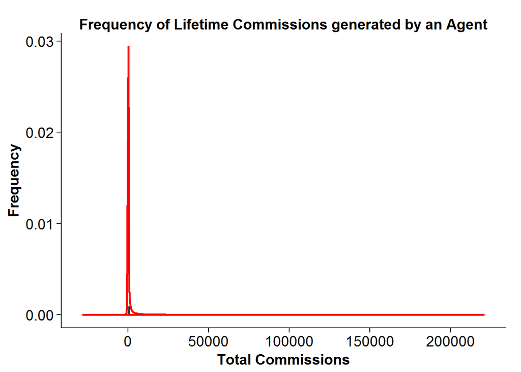

The Commissions range from a low (debt) of about $28,000 to a positive contribution of just over $220,000; the distribution of lifetime agent commisisons is heavily skewed, with a large contingen of agents that either do not contribute revenue to AmeriLife or are a debt burden to the organization. The basic statistics of this distribution are:

```
##     Min.  1st Qu.   Median     Mean  3rd Qu.     Max.
## -27990.0      0.0      0.0    478.7    102.0 220500.0
```

A manually binned histogram of those commissions by range of revenue looks as follows:

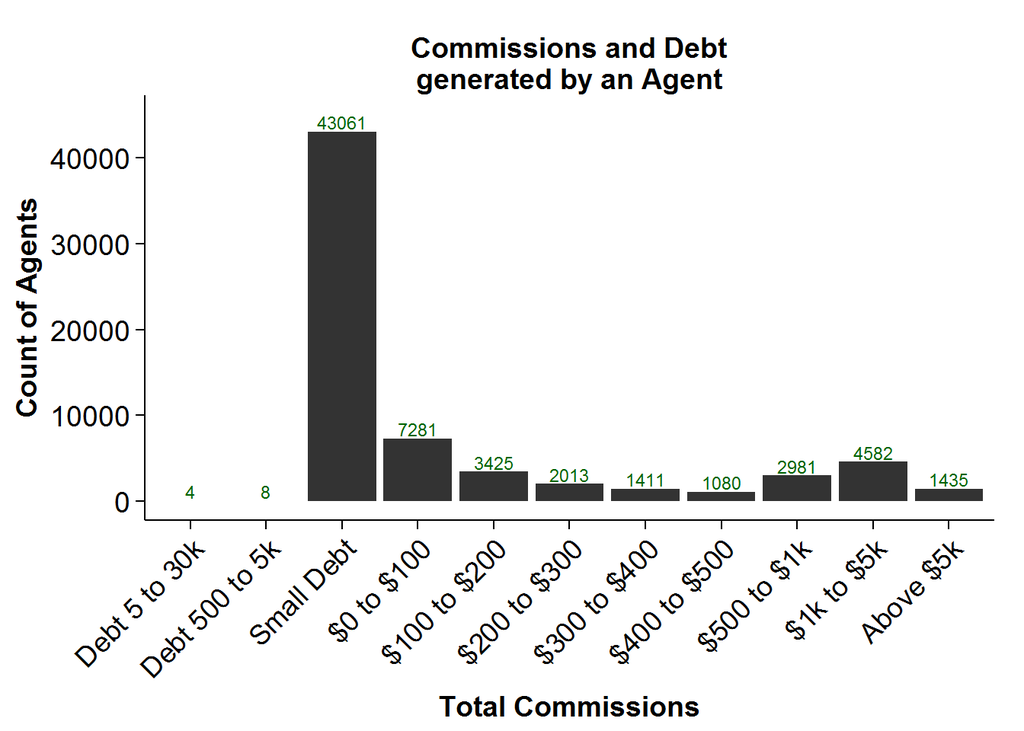

In tabular form:

| CommissionBinned | Freq |
| --- | --- |
| Debt 5 to 30k | 4 |
| Debt 500 to 5k | 8 |
| Small Debt | 43061 |
| $0 to $100 | 7281 |
| $100 to $200 | 3425 |
| $200 to $300 | 2013 |
| $300 to $400 | 1411 |
| $400 to $500 | 1080 |
| $500 to $1k | 2981 |
| $1k to $5k | 4582 |
| Above $5k | 1435 |

Given that enrolling an agent to sell for AmeriLife carries an initial estimated cost of $400, it behooves us to find out what are the attributes of agents that are capable of generating more that that amount in revenue through their lifetime.

### By Type of Agent: Direct vs. Downline Agents

Before leaving the analysis of lifetime commissions it is worth noting that at every level of revenue, there appears to be a larger number of direct agents vs. downline agents achieving that revenue. Here are some examples:

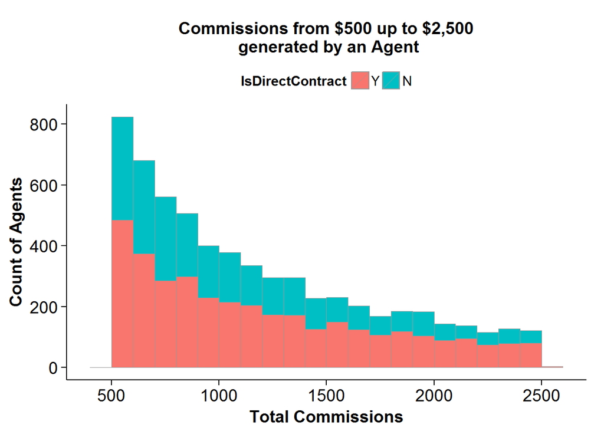

In this range of revenue generation, the proportion of direct vs. downline contracts is mor even than in any other range.

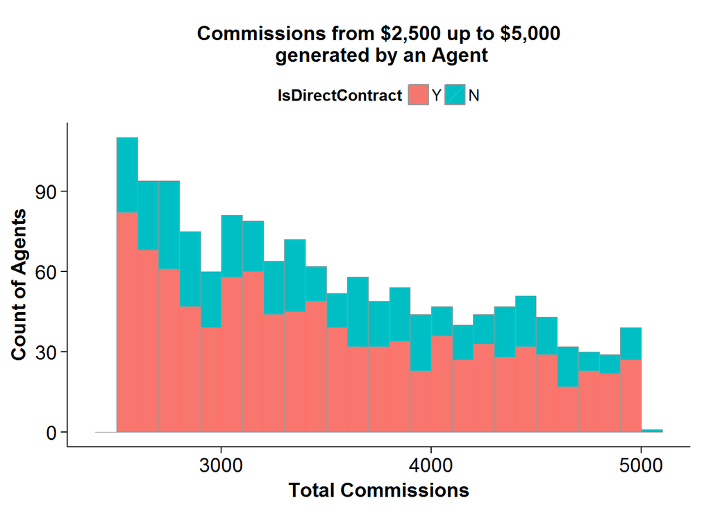

As revenue begins to increase, the proportion of direct agents generating the revenue increases with respect tot he downline agents generating the same volume of revenue.

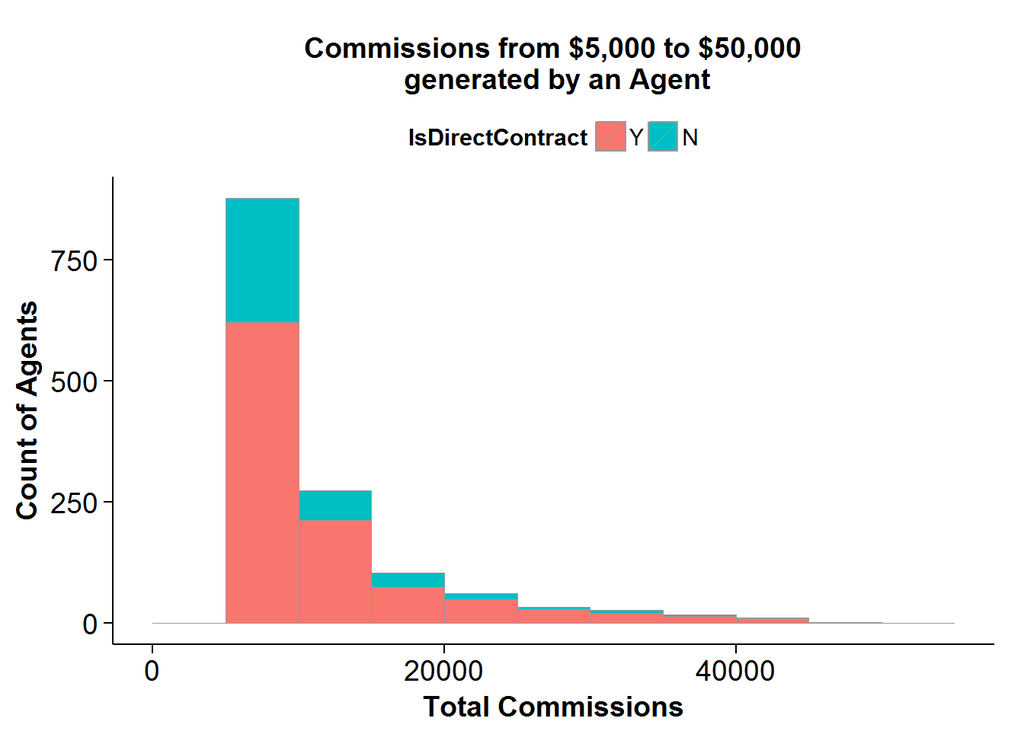

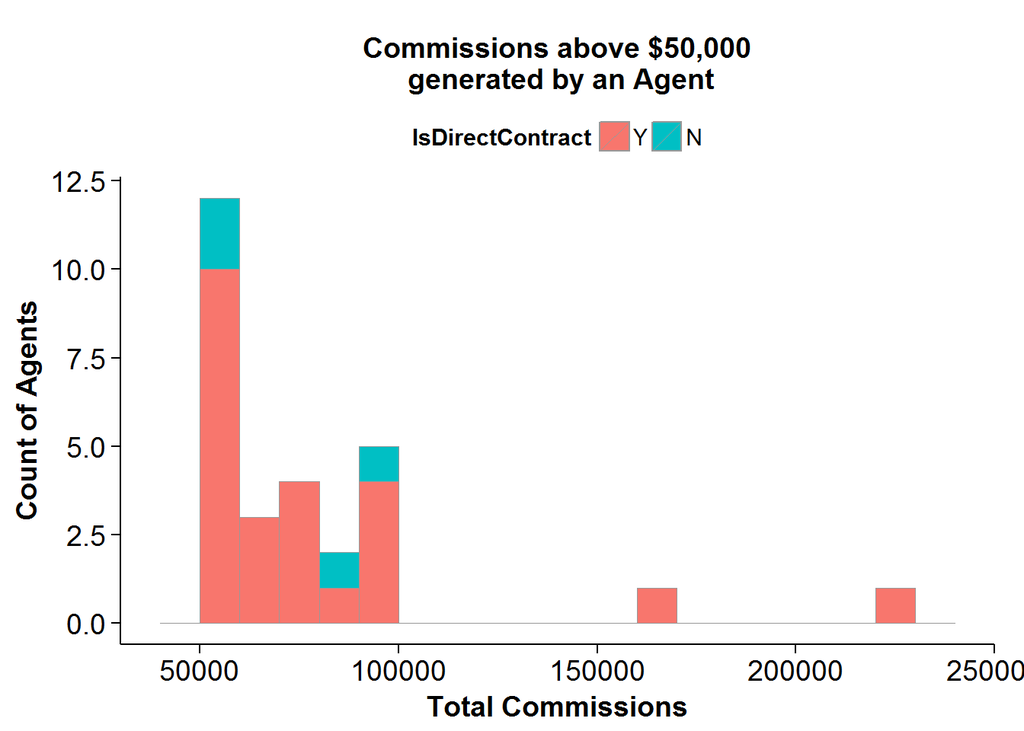

# Commissions Generated by an Agent in the first 12 months from Contract Completed

Does the Agent’s ability to generate revenue for AmeriLife happen shortly after the Agent is Contracted or does it take a long time? In this section we present the same graphs that were developed above for Lifetime Commissions but focus exclusively on the Commissions that an Agent generates thorugh a contract during the first 12 months from the Contract Completed date.

There is one caveat to this analysis: We do not eliminate any contracts from the analysis even if the contract has not accumulated 12 months of revenue from its contract completed date. Since there is a large population of contracts it’s expected that these contracts under 12 months old will not unduly influence the analysis.

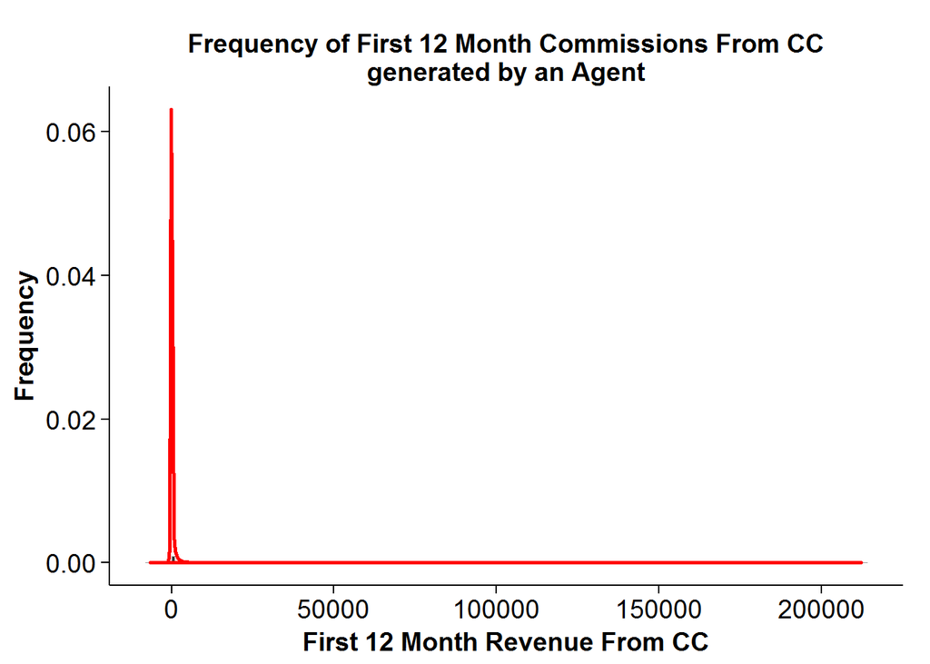

The Commissions range form a low (debt) of $6,500 to a high of just over $212,000; this distribution of values is also heavily skewed as was the distribution of lifetime commissions. The basis statistics of this distribution are:

```
##      Min.   1st Qu.    Median      Mean   3rd Qu.      Max.
##  -6538.00      0.00      0.00    216.00     48.44 212100.00
```

Since the range of values for the commissions generated in the first 12 months of an Agent’s tenure in a contract is almost exactly the same as that of the commissions that the Agent has generated in their lifetime, we bin the data using the same buckets used in the previous section. The histogram of Commissions generated during the first 12 months in a contract’s life follows (nothe the scale of the y axis is different than that of the lifetime commissions):

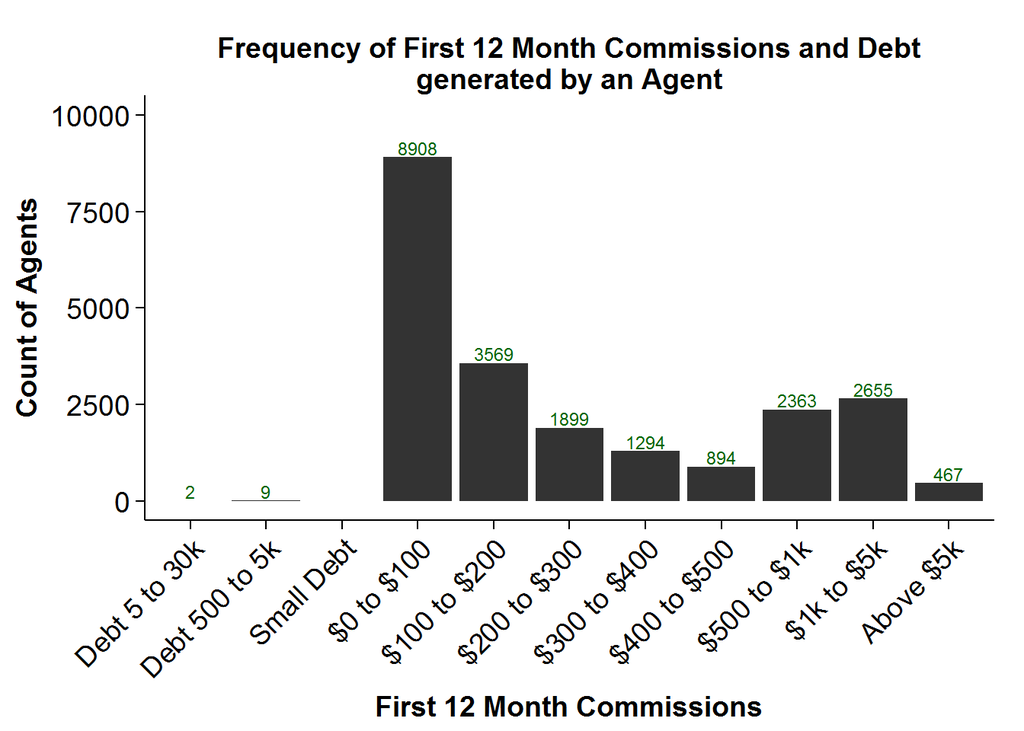

In tabular form:

| CommissionBinned | Freq |
| --- | --- |
| Debt 5 to 30k | 2 |
| Debt 500 to 5k | 9 |
| Small Debt | 45221 |
| $0 to $100 | 8908 |
| $100 to $200 | 3569 |
| $200 to $300 | 1899 |
| $300 to $400 | 1294 |
| $400 to $500 | 894 |
| $500 to $1k | 2363 |
| $1k to $5k | 2655 |
| Above $5k | 467 |

### By Type of Agent: Direct vs. Downline Agents

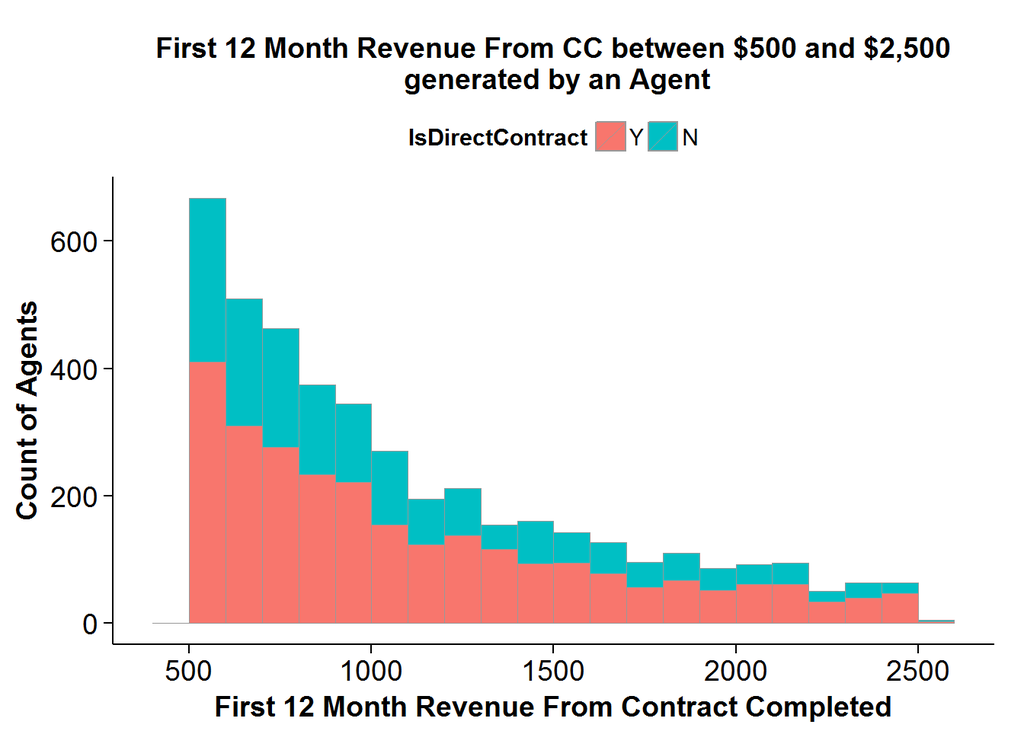

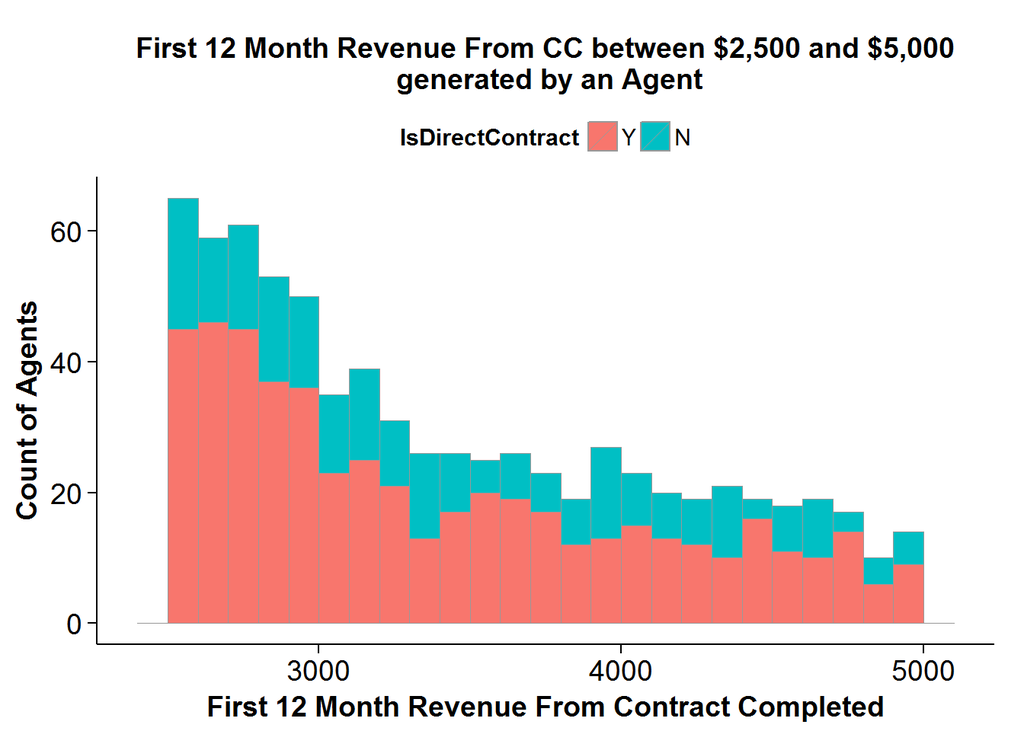

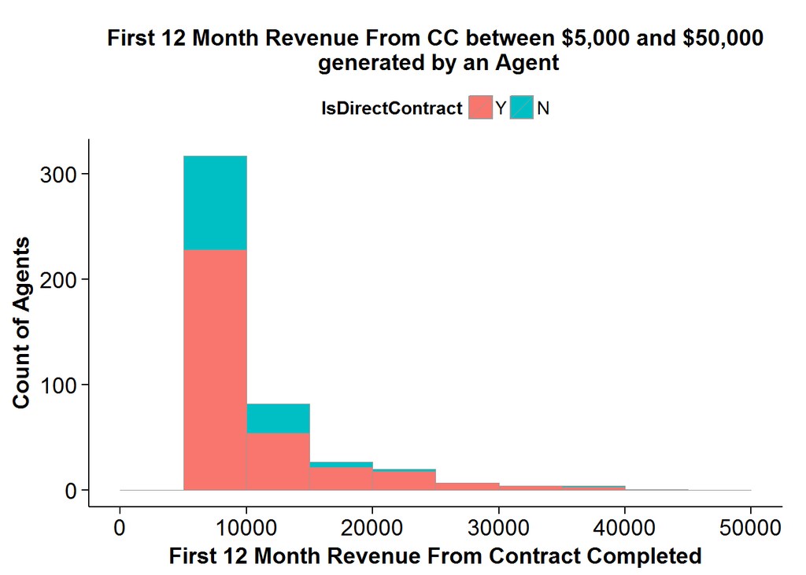

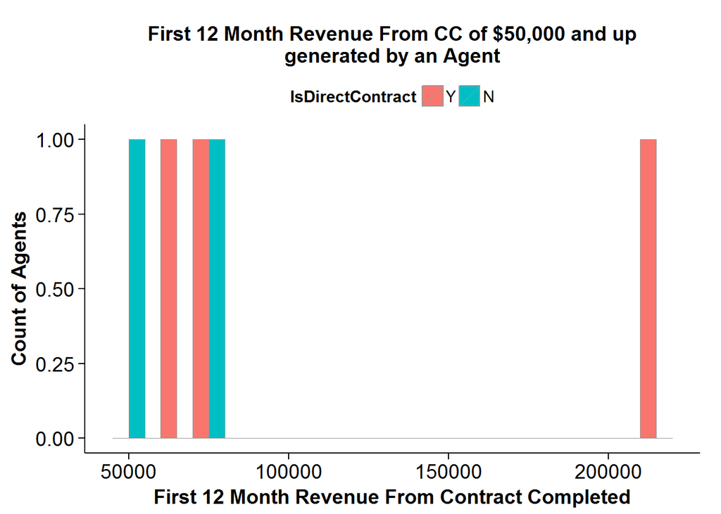

[figure not shown]

# Appendix A: The highest producers

This is a list of the agents that have generated revenue for AmeriLife in excess of $5,000 during their lifetime, ordered by the revenue generated.

| Agent | NPN | CRMGender | CRMState | CRMZipCode | Commission | PolicyCount |
| --- | --- | --- | --- | --- | --- | --- |
| Jonathan Grout | 2714306 | NA | CA | 92109 | 5000.00 | 0 |
| Kassandra Urban | 16890458 | Female | FL | 34471 | 5009.80 | 9 |
| Allen Fingerson | 302188 | Male | MN | 55337 | 5018.76 | 169 |
| Ted Riley | 3979405 | Male | GA | 30523 | 5019.36 | 29 |
| Larry Leib | 17668423 | Male | NJ | 07652 | 5021.11 | 41 |
| Bobby Atkerson | 78045 | Male | NV | 89503 | 5021.49 | 28 |
| Howard Schachter | 3647838 | Male | CT | 06457 | 5022.68 | 0 |
| Danny Laster | 5952351 | Male | KY | 42220 | 5022.85 | 49 |
| Saidang Xiong | 7758808 | NA | MN | 55042 | 5025.05 | 0 |
| Ricky Nolan | 1501343 | NA | SC | 29512 | 5026.85 | 66 |
| Reggie Jones | 138557 | Male | MT | 97501 | 5027.91 | 5 |
| Robin Millet | 12269815 | NA | LA | 70769 | 5034.60 | 63 |
| Vaughn Dunlap | 1436846 | Male | GA | 30655 | 5034.75 | 5 |
| Darien Teeter | 115150 | NA | MO | 65753 | 5042.52 | 69 |
| Mario Wayne | 15869587 | Male | MO | 63044 | 5043.43 | 0 |
| Paula A Llorens | 8460942 | Female | GA | 30019 | 5044.55 | 34 |
| Francisco Maribona | 131755 | Male | OR | 97367 | 5044.82 | 60 |
| David Brown | 15901551 | Male | KS | 66210 | 5045.28 | 77 |
| Roy Mills | 17112844 | Male | NC | 27330 | 5047.13 | 70 |
| Matthew Gouin | 8707007 | NA | SC | 29485 | 5050.42 | 86 |
| Robert Stout | 10958875 | Male | CO | 80305 | 5052.27 | 80 |
| Travis Robinson | 7905563 | Male | MS | 39114 | 5059.98 | 36 |
| Khalid Kamalmaz | 16295585 | NA | IN | 46410 | 5060.73 | 125 |
| Su Chuang | 5775551 | NA | WA | 98008 | 5064.49 | 0 |
| Youngshin Jae | 10941143 | NA | NJ | 07657 | 5064.66 | 2 |
| Chadwick Taber | 16485064 | NA | OK | 74135 | 5070.18 | 103 |
| Douglas Mac Vittie | 7104497 | Male | NY | 11716 | 5070.18 | 56 |
| Louis Partazana | 7634287 | Male | FL | 34667 | 5071.72 | 8 |
| Barbara Jones | 1474362 | Female | KY | 42420 | 5072.51 | 9 |
| John Cochran | 8501109 | Male | FL | 34238 | 5073.70 | 59 |

[output cut: 1406 more lines]